# ollmaでLLMを動かしてRで遊ぼう

国里愛彦

## LLM

- いやあ！すごいっすね！
- DeepSeekはなんかワクワクしました。

## Ollama

- Ollamaを使えば，超簡単にオープンソースになっているLLMをローカルで使えます（もうAPI代や個人情報を気にしなくてもよい？）
- PythonをつかっOllama上で動かしているLLMとやり取りすればいいんだけど，Rでやりたいんですよね〜
- でもRのhttrとかで書くのちょっと面倒なんです。

## ollamar

- 探してみたら，OllamaをRで使うという意味不明な要求に答えるパッケージがあった・・・（python使えと言われそうな話）

https://github.com/hauselin/ollama-r

- インストールして使ってみる。

```r
library(ollamar)
```

## おしゃべりしてみよう!

- APIとのやりとりがめちゃくちゃ単純！`generate()`でモデルとプロンプトを指定するだけ！

```r
resp <- generate("deepseek-r1:70b",
                 "ベイズ統計学について簡潔に説明してください。回答は日本語でお願いします。")
```

- “deepseek-r1:70b”は，中国語で考えるっぽくで “嗯，用…易理解。…”みたいなのが入るので，除外します。

```r
text <- resp_process(resp, "text")
gsub("^.*?</think>\n\n", "", text)
```

```
[1] "ベイズ統計学は、確率論を基盤とした统计学の一分野です。主に、ベイズ定理を活用して、データや観測結果をもとに事後の分布（後验分布）を求めます。また、事前の知識や信念を表す先验分布を利用し、これをデータで更新して推論を行います。\n\n### 主な特徴：\n1. **確率の解釈**: ベイズ統計学では、確率はイベントの起こりやすさではなく、信念の度合や不確実性を表します。\n2. **先验分布と後验分布**: 分析前に持つ情報（先验分布）をデータで更新し、事後の分布（後验分布）を求めます。\n3. **ベイズ定理**: 事前確率、証拠、モデル間の関連性を組み合わせて事後確率を計算します。…
```

## ベクトル埋め込み技術

- TIPI-Jの10項目をベクトル埋め込み技術をつかって，ベクトルにする。`embed()`でモデルと文章を指定するだけ。

```r
tipi1 <- embed("deepseek-r1:70b", "活発、外向的だと思う。") |> as.vector()
tipi2 <- embed("deepseek-r1:70b", "他人に不満をもち、もめごとを起こしやすいと思う。") |> as.vector()
tipi3 <- embed("deepseek-r1:70b", "しっかりしていて、自分に厳しいと思う。") |> as.vector()
tipi4 <- embed("deepseek-r1:70b", "心配性で、うろたえやすいと思う。") |> as.vector()
tipi5 <- embed("deepseek-r1:70b", "新しいことが好きで、変わった考えをもつと思う。") |> as.vector()
tipi6 <- embed("deepseek-r1:70b", "ひかえめで、おとなしいと思う。") |> as.vector()
tipi7 <- embed("deepseek-r1:70b", "人に気をつかう、やさしい人間だと思う。") |> as.vector()
tipi8 <- embed("deepseek-r1:70b", "だらしなく、うっかりしていると思う。") |> as.vector()
tipi9 <- embed("deepseek-r1:70b", "冷静で、気分が安定していると思う。") |> as.vector()
tipi10 <- embed("deepseek-r1:70b", "発想力に欠けた、平凡な人間だと思う。") |> as.vector()
matrix_tipi <- do.call(rbind, lapply(paste0("tipi", 1:10), get))
```

## コサイン類似度

- 項目をベクトル化したもののコサイン類似度を計算します。

```r
library(lsa)
# コサイン類似度
similarity_matrix <- cosine(t(matrix_tipi))
```

## ネットワークにしてみる

```r
library(qgraph)
qgraph(similarity_matrix,
       layout = "spring",
       labels = c("E1","A1","C1","N1","O1","E2","A2","C2","N2","O2"),
       edge.width = 0.5,
       vsize = 5,
       threshold = 0.7)
```

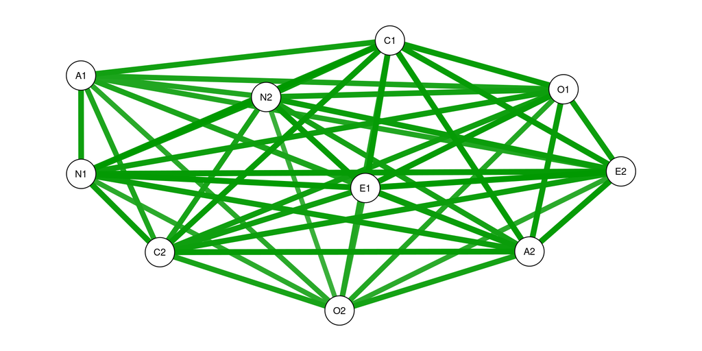

## オープンLLMを使って心理学研究を！

- 実験の刺激など既に多くの研究者が生成AIを活用し始めている。
- 質問項目の作成と検討を自動化する研究もすでにある。商用だとAPIの利用料が不安だけど，オープンならば色々と練習で試すのにも良いかもしれない。
- SLM(Small Language Models)のファインチューニングは心理学者でも可能なレベルの計算資源でできる。